# Block 2 ex 6

Facchin Tommaso

Consider a study on the behavior of customers of an online shop and on the relationship between sales and appreciation of the website. A certain number of website visitors were asked to rate their appreciation of the website on a 5‑point Likert scale, ranging from 1 (terrible) to 5 (excellent). For these visitors it was also recorded whether they actually bought something on the website. The data are contained in the file online.txt.

```r
dex <- read.table("../Datasets/online.txt.", sep=",", header = TRUE)
head(dex)
```

```
##   appreciation.buy
## 1            4 yes
## 2            4 yes
## 3             3 no
## 4             4 no
## 5            2 yes
## 6            3 yes
```

### 1. What type of variables are involved?

Appreciation is a ordinal categorical variable and buy is a binary categorical variable.

### 2. Consider a website visitor and suppose we have no information about how much this customer appreciates the website. Estimate the probability that this customer actually purchased something.

$$\hat{p} = \frac{\text{number of visitors with buy =
"yes"}}{\text{total number of visitors}}.$$

### 3. Estimate the probability of purchasing something separately for each appreciation level and show in a plot the estimated probabilities as a function of appreciation.

```r
tmp <- do.call(rbind, strsplit(dex$appreciation.buy, " "))

dex$appreciation <- as.integer(tmp[, 1])
dex$buy          <- tmp[, 2]

str(dex)
```

```
## 'data.frame':    47 obs. of  3 variables:
##  $ appreciation.buy: chr  "4 yes" "4 yes" "3 no" "4 no" ...
##  $ appreciation    : int  4 4 3 4 2 3 3 3 5 2 ...
##  $ buy             : chr  "yes" "yes" "no" "no" ...
```

```r
head(dex)
```

```
##   appreciation.buy appreciation buy
## 1            4 yes            4 yes
## 2            4 yes            4 yes
## 3             3 no            3  no
## 4             4 no            4  no
## 5            2 yes            2 yes
## 6            3 yes            3 yes
```

```r
tab <- table(dex$appreciation, dex$buy)
prob_by_app <- prop.table(tab, margin = 1)
prob_by_app
```

```
##
##            no       yes
##   1 0.7500000 0.2500000
##   2 0.7142857 0.2857143
##   3 0.5384615 0.4615385
##   4 0.3000000 0.7000000
##   5 0.1111111 0.8888889
```

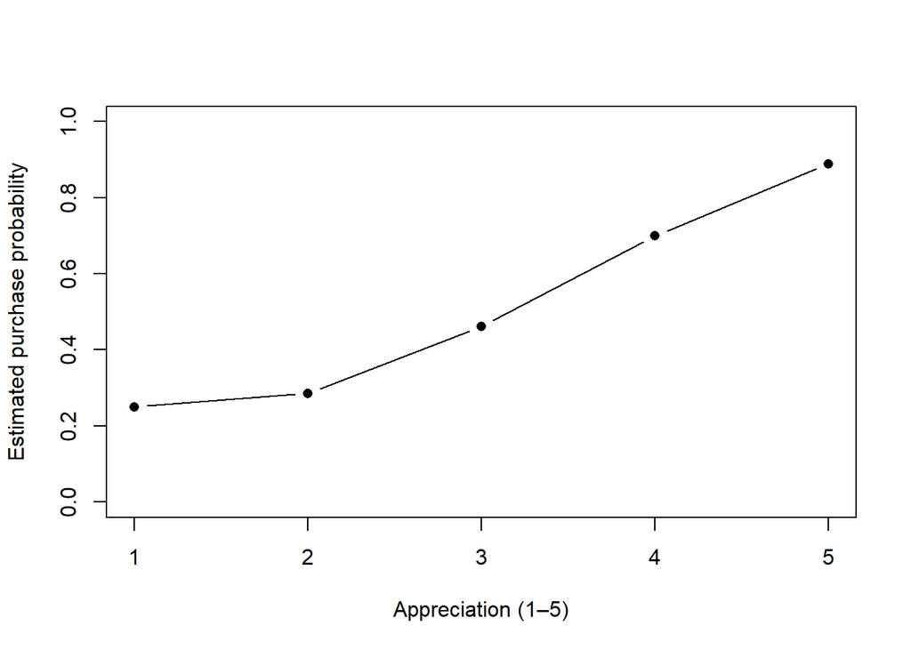

```r
p_yes <- prob_by_app[, "yes"]

plot(
  as.numeric(rownames(prob_by_app)), p_yes,
  type = "b", pch = 16,
  xlab = "Appreciation (1–5)",
  ylab = "Estimated purchase probability",
  ylim = c(0, 1)
)
```

### 4. Explain why it does not make sense to specify a linear model to describe the relationship between the two variables.

It does not make sense because the **response is binary** (buy: yes/no), so a linear model would violate key assumptions and give invalid probabilities.

- A linear regression can predict values **below 0 or above 1**, which are impossible as probabilities.
- With a binary outcome the variance depends on the mean, so the errors are strongly **heteroskedastic**, contradicting the constant-variance assumption of linear regression.
- Logistic regression instead models the log‑odds, guaranteeing fitted values between 0 and 1 and using a distribution (Bernoulli/binomial) appropriate for yes/no data.

### 5. Estimate an appropriate logistic regression model.

```r
dex$buy <- factor(dex$buy, levels = c("no", "yes"))

fit_logit <- glm(buy ~ appreciation,
                 data   = dex,
                 family = binomial)

summary(fit_logit)
```

```
##
## Call:
## glm(formula = buy ~ appreciation, family = binomial, data = dex)
##
## Coefficients:
##              Estimate Std. Error z value Pr(>|z|)
## (Intercept)   -2.3194     0.9082  -2.554  0.01065 *
## appreciation   0.7948     0.2760   2.880  0.00398 **
## ---
## Signif. codes:  0 '***' 0.001 '**' 0.01 '*' 0.05 '.' 0.1 ' ' 1
##
## (Dispersion parameter for binomial family taken to be 1)
##
##     Null deviance: 64.964  on 46  degrees of freedom
## Residual deviance: 54.453  on 45  degrees of freedom
## AIC: 58.453
##
## Number of Fisher Scoring iterations: 4
```

### 6. Is it true that the website appreciation variable has an effect on the probability of purchase? If so, what is this effect? How strong is the evidence supporting your statement?

Yes, from the logistic regression `buy ~ appreciation`, if the coefficient of **appreciation** is positive and its p‑value is < 0.05, we conclude that higher appreciation increases the purchase probability.  
The strength of the evidence is summarized by the p‑value (smaller means stronger evidence) and by the odds ratio $e^{\hat\beta_1}$, which tells how many times the odds of purchase multiply for a one‑point increase in appreciation.